# iris data Analysis

Mayuri Borate

03/02/2020

# first import the data

```r
iris=iris
dim(iris)
```

```
## [1] 150   5
```

```r
str(iris)
```

```
## 'data.frame':    150 obs. of  5 variables:
##  $ Sepal.Length: num  5.1 4.9 4.7 4.6 5 5.4 4.6 5 4.4 4.9 ...
##  $ Sepal.Width : num  3.5 3 3.2 3.1 3.6 3.9 3.4 3.4 2.9 3.1 ...
##  $ Petal.Length: num  1.4 1.4 1.3 1.5 1.4 1.7 1.4 1.5 1.4 1.5 ...
##  $ Petal.Width : num  0.2 0.2 0.2 0.2 0.2 0.4 0.3 0.2 0.2 0.1 ...
##  $ Species     : Factor w/ 3 levels "setosa","versicolor",..: 1 1 1 1 1 1 1 1 1 1 ...
```

in iris data contains 150 rows(observation) and 5 columns(variable) in which 4 are numeric and one is categorical.

# summary of data

```r
summary(iris)
```

```
##   Sepal.Length    Sepal.Width     Petal.Length    Petal.Width
##  Min.   :4.300   Min.   :2.000   Min.   :1.000   Min.   :0.100
##  1st Qu.:5.100   1st Qu.:2.800   1st Qu.:1.600   1st Qu.:0.300
##  Median :5.800   Median :3.000   Median :4.350   Median :1.300
##  Mean   :5.843   Mean   :3.057   Mean   :3.758   Mean   :1.199
##  3rd Qu.:6.400   3rd Qu.:3.300   3rd Qu.:5.100   3rd Qu.:1.800
##  Max.   :7.900   Max.   :4.400   Max.   :6.900   Max.   :2.500
##        Species
##  setosa    :50
##  versicolor:50
##  virginica :50
##
##
##
```

### Data cleaning

```r
m=function(x){sum(is.na(x))}
apply(iris,2,m)
```

```
## Sepal.Length  Sepal.Width Petal.Length  Petal.Width      Species
##            0            0            0            0            0
```

in iris data thier is no missing value present.

# EDA (Data Visualization)

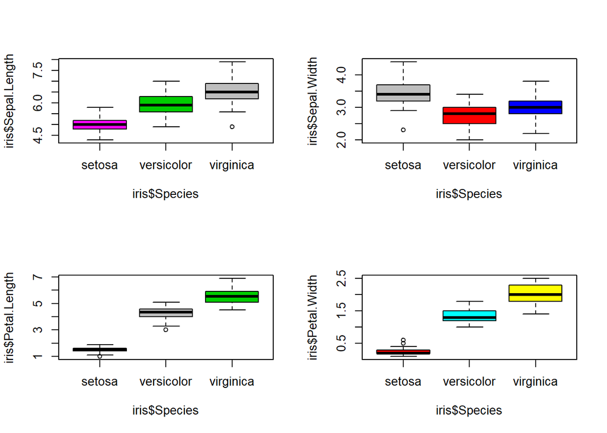

```r
library(ggplot2)
library(plotly)
library(billboarder)
par(mfrow=c(2,2))
boxplot(iris$Sepal.Length ~ iris$Species,col=c(6,3,8))
boxplot(iris$Sepal.Width~iris$Species,col=c(8,18,28))
boxplot(iris$Petal.Length~iris$Species,col=c(1,8,19))
boxplot(iris$Petal.Width~iris$Species,col=c(2,5,7))
```

```r
t=table(iris$Species)
billboarder()%>%bb_piechart(data=t)
```

[interactive chart not shown]

from above boxplot we would predict that, all numeric columns i.e sepal length, sepal width,petal length,petal width,petal width are effected on species.

Now we want to predict the species category based on that 4 numeric features or columns so we are going to classification algorithms

## split the data into train and test set.

```r
library(caret)
set.seed(18)## set the seed to stabilize our output
partition=createDataPartition(y=iris$Species,p=0.7,list = FALSE)

iris_train=iris[partition,]
iris_test=iris[-partition,]
dim(iris_train)
```

```
## [1] 105   5
```

```r
dim(iris_test)
```

```
## [1] 45  5
```

### fit the model

```r
fit_knn=knn3(Species~.,data = iris_train[1:5],k=5)
```

### prediction

```r
iris_predk=predict(fit_knn,newdata = iris_test[,-5],type = "class")
```

## model evaluation (check accuracy of the model)

```r
tl_1=table(iris_predk,iris_test[,5],dnn = list('pred','actual'))
confusionMatrix(tl_1)
```

```
## Confusion Matrix and Statistics
##
##             actual
## pred         setosa versicolor virginica
##   setosa         15          0         0
##   versicolor      0         14         0
##   virginica       0          1        15
##
## Overall Statistics
##
##                Accuracy : 0.9778
##                  95% CI : (0.8823, 0.9994)
##     No Information Rate : 0.3333
##     P-Value [Acc > NIR] : < 2.2e-16
##
##                   Kappa : 0.9667
##
##  Mcnemar's Test P-Value : NA
##
## Statistics by Class:
##
##                      Class: setosa Class: versicolor Class: virginica
## Sensitivity                 1.0000            0.9333           1.0000
## Specificity                 1.0000            1.0000           0.9667
## Pos Pred Value              1.0000            1.0000           0.9375
## Neg Pred Value              1.0000            0.9677           1.0000
## Prevalence                  0.3333            0.3333           0.3333
## Detection Rate              0.3333            0.3111           0.3333
## Detection Prevalence        0.3333            0.3111           0.3556
## Balanced Accuracy           1.0000            0.9667           0.9833
```

we used the knn this model is good fit on iris data.

### Naive Bayes algorithm

##fit the model

```r
library(e1071)
fit_nb=naiveBayes(iris_train[,-5],iris_train$Species)
```

## Make prediction

```r
pred_nb=predict(fit_nb,new=iris_test[,-5],type="class")
```

## Model Evaluation

```r
tbl_nb=table(pred_nb,iris_test[,5],dnn = list('pred','actual'))
confusionMatrix(tbl_nb)
```

```
## Confusion Matrix and Statistics
##
##             actual
## pred         setosa versicolor virginica
##   setosa         15          0         0
##   versicolor      0         12         0
##   virginica       0          3        15
##
## Overall Statistics
##
##                Accuracy : 0.9333
##                  95% CI : (0.8173, 0.986)
##     No Information Rate : 0.3333
##     P-Value [Acc > NIR] : < 2.2e-16
##
##                   Kappa : 0.9
##
##  Mcnemar's Test P-Value : NA
##
## Statistics by Class:
##
##                      Class: setosa Class: versicolor Class: virginica
## Sensitivity                 1.0000            0.8000           1.0000
## Specificity                 1.0000            1.0000           0.9000
## Pos Pred Value              1.0000            1.0000           0.8333
## Neg Pred Value              1.0000            0.9091           1.0000
## Prevalence                  0.3333            0.3333           0.3333
## Detection Rate              0.3333            0.2667           0.3333
## Detection Prevalence        0.3333            0.2667           0.4000
## Balanced Accuracy           1.0000            0.9000           0.9500
```

Naive Bayes model also fit on iris data.

## fit model

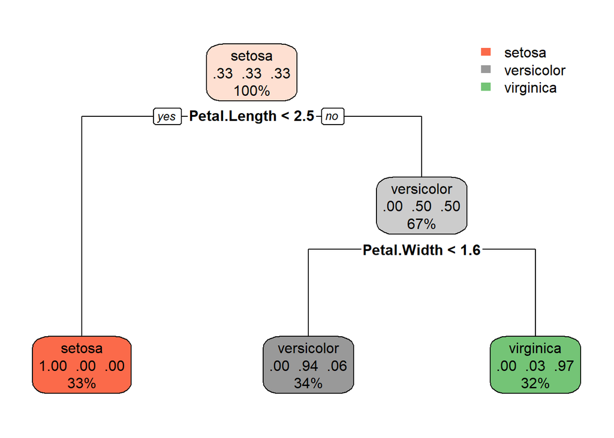

```r
library(rpart)
library(rpart.plot)
iris_tree=rpart(Species~.,data = iris_train,method = "class")
rpart.plot(iris_tree)
```

from above tree plot we get the species classification criteria : when petal.length < 2.5 then species category is setosa. when petal.length>2.5, Petal.width<1.6 then species category is versicolor. when petal.length>2.5, petal.width>1.6 then species category is virginica.

### Prediction

```r
pred_dt=predict(iris_tree,iris_test[,-5],type = "class")
```

## model Evaluation

```r
tbl_dt=table(pred_dt,iris_test[,5],dnn = list('pred','actual'))
confusionMatrix(tbl_dt)
```

```
## Confusion Matrix and Statistics
##
##             actual
## pred         setosa versicolor virginica
##   setosa         15          0         0
##   versicolor      0         11         1
##   virginica       0          4        14
##
## Overall Statistics
##
##                Accuracy : 0.8889
##                  95% CI : (0.7595, 0.9629)
##     No Information Rate : 0.3333
##     P-Value [Acc > NIR] : 1.408e-14
##
##                   Kappa : 0.8333
##
##  Mcnemar's Test P-Value : NA
##
## Statistics by Class:
##
##                      Class: setosa Class: versicolor Class: virginica
## Sensitivity                 1.0000            0.7333           0.9333
## Specificity                 1.0000            0.9667           0.8667
## Pos Pred Value              1.0000            0.9167           0.7778
## Neg Pred Value              1.0000            0.8788           0.9630
## Prevalence                  0.3333            0.3333           0.3333
## Detection Rate              0.3333            0.2444           0.3111
## Detection Prevalence        0.3333            0.2667           0.4000
## Balanced Accuracy           1.0000            0.8500           0.9000
```

decision tree also good fit on iris data.

### Now i want to test my model on self created data

```r
cr_iris=read.csv("F:\\iris created data.csv")
head(cr_iris)
```

```
##   Sepal.Length Sepal.Width Petal.Length Petal.Width
## 1         4.50         2.0         1.80        0.75
## 2         7.20         2.6         5.28        1.90
## 3         6.90         2.9         6.80        2.00
## 4         5.80         3.5         4.20        2.20
## 5         4.18         4.0         4.60        0.25
## 6         6.18         3.7         1.70        1.75
```

```r
str(cr_iris)
```

```
## 'data.frame':    10 obs. of  4 variables:
##  $ Sepal.Length: num  4.5 7.2 6.9 5.8 4.18 6.18 6.35 7.8 5.28 6.45
##  $ Sepal.Width : num  2 2.6 2.9 3.5 4 3.7 3.2 3.7 2.28 2.25
##  $ Petal.Length: num  1.8 5.28 6.8 4.2 4.6 1.7 4.35 6.2 1.64 2.22
##  $ Petal.Width : num  0.75 1.9 2 2.2 0.25 1.75 2.5 2.35 1.5 0.8
```

## prediction KNN

```r
cr_knn_pred= predict(fit_knn,newdata = cr_iris,type = "class")
```

## prediction Naive Bayes

```r
cr_nb_pred=predict(fit_nb,new=cr_iris,type="class")
```

### prediction Decision tree

```r
cr_dt_pred=predict(iris_tree,cr_iris,type = "class")
```

## Camparison of three model similarity prediction

```r
m=data.frame(cr_knn_pred,cr_nb_pred,cr_dt_pred)
m
```

```
##    cr_knn_pred cr_nb_pred cr_dt_pred
## 1       setosa     setosa     setosa
## 2    virginica  virginica  virginica
## 3    virginica  virginica  virginica
## 4   versicolor  virginica  virginica
## 5   versicolor versicolor versicolor
## 6       setosa versicolor     setosa
## 7    virginica  virginica  virginica
## 8    virginica  virginica  virginica
## 9       setosa versicolor     setosa
## 10  versicolor versicolor     setosa
```

6 observations are same prediction of all three model may be its true prediction.